# POLISCI 9590 - Lab6: Confidence Intervals

William Poirier

2024-10-29

## 0. What we’ll be doing

1. Confidence Intervals
2. Exercises

## 1. Confidence Intervals

### 1.1 The reality of inference

Let’s have a **population distribution**:

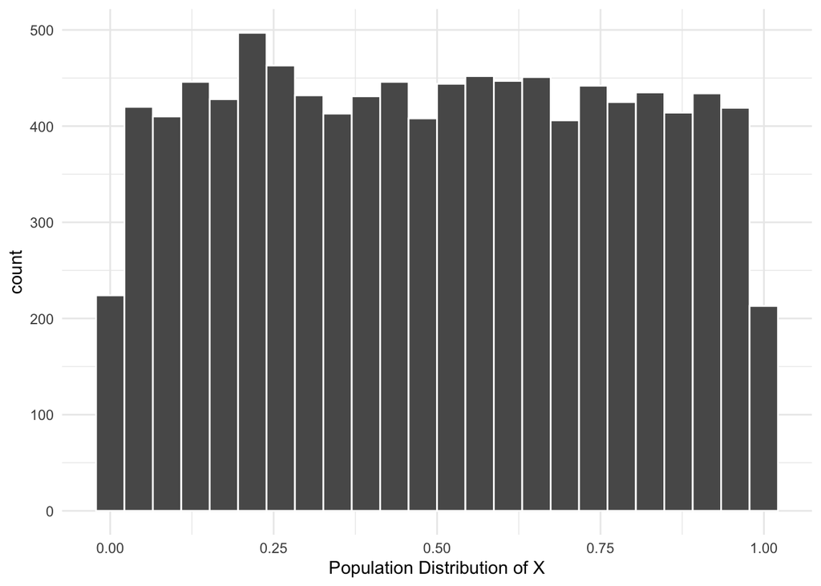

```r
library(tidyverse)

set.seed(2543)
pop <- runif(10000,0,1)

ggplot()+
  geom_histogram(aes(x=pop),bins=24,color="white")+
  theme_minimal()+
  xlab("Population Distribution of X")
```

Where the true population mean $\mu$ is:

```r
mean(pop)
```

```
## [1] 0.49728
```

and the true population SD $\sigma$ is:

```r
sqrt(sum((pop - mean(pop))^2)/length(pop))
```

```
## [1] 0.2872507
```

Let’s take a **sample** of size 100 at random from the population:

```r
samp <- sample(pop, 100, replace = TRUE)

# Sample mean
mean(samp)
```

```
## [1] 0.4871019
```

```r
# Sample sd
sd(samp)
```

```
## [1] 0.2748858
```

Hence, the **sampling error** is $\bar x- \mu$:

```r
mean(samp)-mean(pop)
```

```
## [1] -0.0101781
```

**QUESTIONS:**

1. What would happen if I were to take bigger and bigger samples? Why?
2. What would happen if I took 1000 samples of a 100 individuals? Why?

So, let’s take a 1000 sample of a 100:

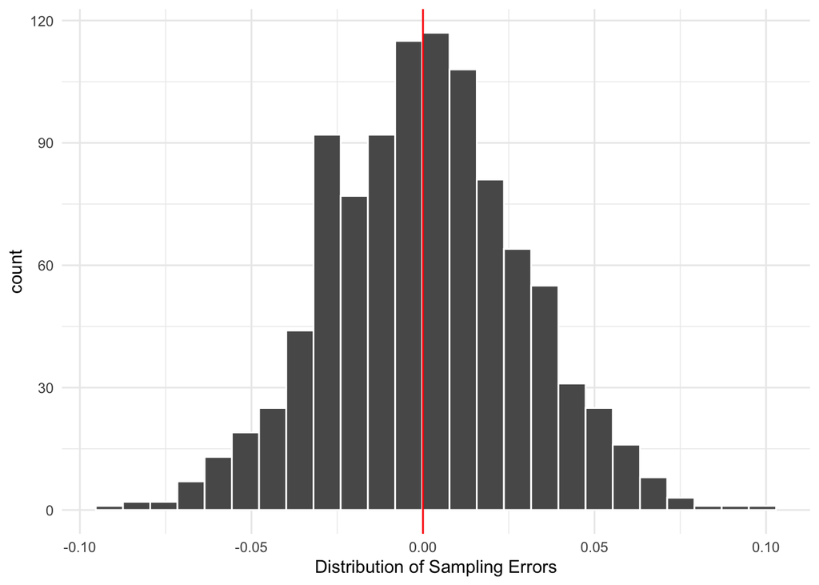

```r
means <- replicate(1000,
                   mean(
                     sample(pop, 100, replace=TRUE)
                     )
                   )
samp.errors <- means - mean(pop)
ggplot() +
  geom_histogram(aes(x=samp.errors),bins=25,col="white") +
  theme_minimal() +
  geom_vline(xintercept=0, col="red") +
  labs(x="Distribution of Sampling Errors")
```

We get a **sampling distribution**, the distribution of the sample means around the true, but generally unkown, population mean.

THE ISSUE IS (as the real slim shady would say) :

[figure not shown]

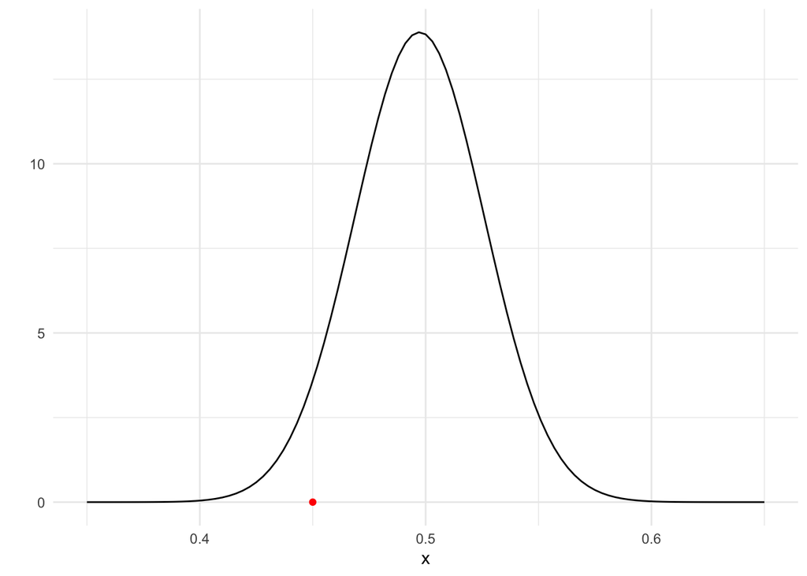

We would like to be able to identify how likely it is that we would observe our sample statistic ($\bar x=.45$) in the population :

```r
pnorm(.45, mean(pop), true.se)
```

```
## [1] 0.04988717
```

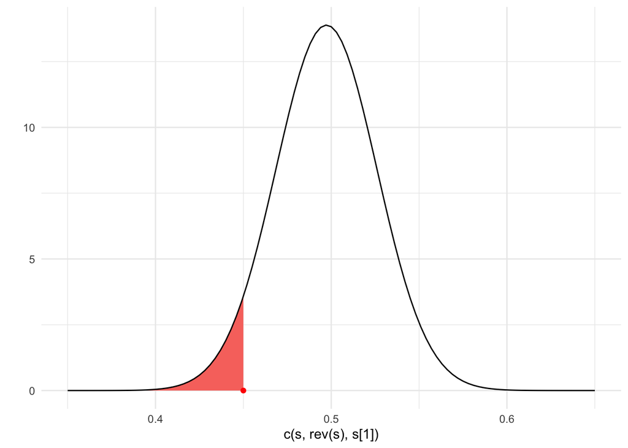

And we have:

1. The sample mean ($\bar x$);
2. The sample standard deviation ($sd$).

### 1.2 Formulas & R

If we know $\sigma_{\bar{x}}$ (unlikely)

$$\bar{x} \pm
z_{\text{crit}}\frac{\sigma_{x}}{\sqrt{n}}$$
If we have to estimate $\hat{\sigma}_{\bar{x}} = s_{\bar{x}}$, then:

$$\bar{x} \pm
z_{\text{crit}}\frac{s_{x}}{\sqrt{n}}$$

If we have small samples $(n < 120)$:

$$\bar{x} \pm
t_{\text{crit}}\frac{s_{x}}{\sqrt{n}}$$
Note: the formula doesn’t require us to know $\mu$, which is nice.

From `ggplot2`, use `mean_cl_normal()`:

```r
mean_cl_normal(samp)
```

```
##           y      ymin      ymax
## 1 0.4871019 0.4325586 0.5416452
```

Or, from `uwo4419`, use `confidenceInterval()` (Allows you to choose the distribution you want):

```r
uwo4419::confidenceInterval(samp,distr = "normal")
```

```
##   Estimate   CI lower   CI upper Std. Error
## 0.48710189 0.43322527 0.54097851 0.02748858
```

```r
uwo4419::confidenceInterval(samp,distr = "t")
```

```
##   Estimate   CI lower   CI upper Std. Error
## 0.48710189 0.43255859 0.54164519 0.02748858
```

### 1.3 Building the intuition

- **There can only be ONE!!!** How do we know where our sample stand in the sampling distribution???

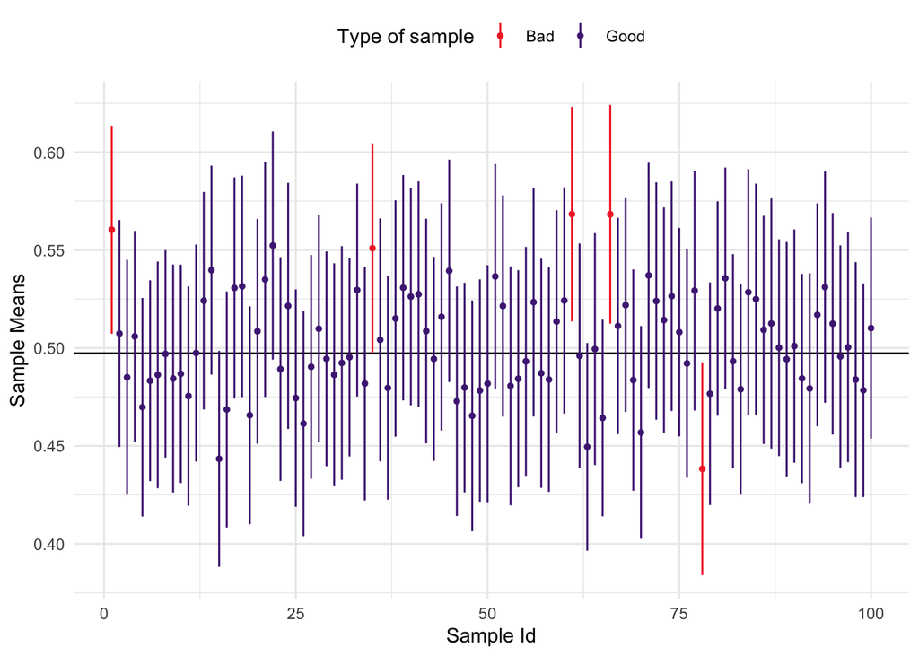

```r
set.seed(122)
# Take 100 sample of size n and compute their means and CI
it <- 100
n <- 100
cis <- lapply(1:it,function(x)mean_cl_normal(sample(pop, n, replace=TRUE)))
cis <- do.call(rbind.data.frame, cis) |>
  mutate(Type=ifelse(ymin>mean(pop) | ymax < mean(pop),"Bad","Good"),
         sample=1:it)

ggplot(cis,aes(x=sample,y=y,ymin=ymin,ymax=ymax,color=Type))+
  geom_hline(yintercept=mean(pop))+
  geom_pointrange(size=0.1)+
  scale_color_manual("Type of sample",values=c("#F23030","#4F2683"))+
  labs(y="Sample Means",
       x="Sample Id")+
  theme_minimal()+
  theme(legend.position = "top")
```

- **Confidence intervals**: created such that $(1-\alpha)\%$ of the intervals we could make from different samples will cover the true, but unknown population value.
  - Hence, the only thing we can say is that, if $alpha$ is small enough, we are *willing to bet* that we are in one of the good samples.

## 2. Exercise 1

From the `CES` data:

1. Compute the average score given to each party per province and their confidence intervals.
2. Present these in a graph where the Y axis are the provinces and the X axis the averages.

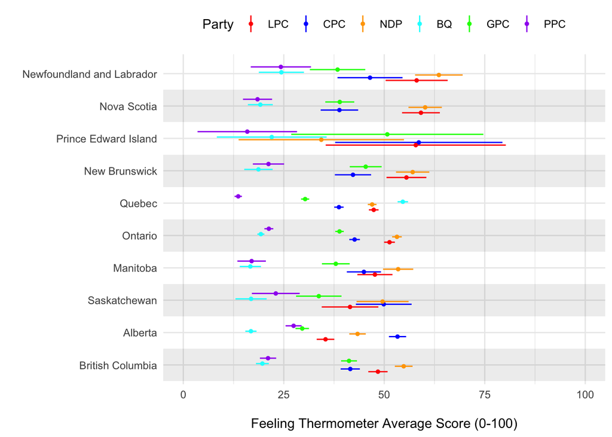

```r
CES |>
  select(UUID,prov,starts_with("pplFeel_")) |>
  select(-pplFeel_Americans,-pplFeel_Francophones) |>
  pivot_longer(c(-UUID,-prov),names_pattern = "pplFeel_(.*)",names_to = "Party", values_to = "score") |>
  group_by(prov,Party) |>
  summarise(ci=mean_cl_normal(score)) |>
  unnest_wider(ci) |>
  mutate(Party=factor(Party,levels=c("LPC","CPC","NDP","BQ","GPC","PPC"))) |>
  ggplot(aes(x=prov,y=y,ymin=ymin,ymax=ymax,color=Party))+
  annotate('rect', xmin = seq(.5,8.5,2), xmax = seq(1.5,9.5,2),
  ymin=-Inf, ymax=Inf, alpha=0.08, fill="black")+
  geom_pointrange(size=0.1,position=position_dodge(0.5)) +
  scale_color_manual(values=c("red","blue","orange","cyan","green","purple"))+
  theme_minimal()+
  theme(legend.position = "top")+
  coord_flip(ylim=c(0,100))+
  labs(x="",y="\nFeeling Thermometer Average Score (0-100)")+
  guides(color = guide_legend(nrow = 1))
```

```r
mean_cl_normal(CES$pplFeel_Americans)
```

```
##       y   ymin   ymax
## 1 54.38 53.823 54.937
```

## 3. Exercise 2

From the `CES` data:

1. Compute the average age of voters for each party and the corresponding CI.
2. Do so using both the normal distribution and the Student’s t distribution. (Hint: use `uwo4419::confidenceInterval()`)
3. Present this in a graph where the Y axis is the averages and the X axis is the parties.

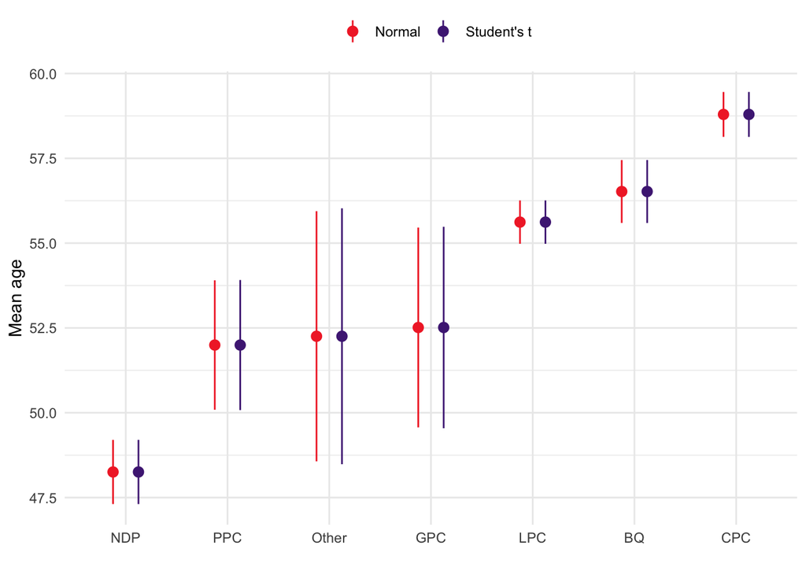

```r
#devtools::install_github("https://github.com/davidaarmstrong/uwo4419.git")
library(uwo4419)
norm <- CES |>
  select(age,vt) |>
  group_by(vt) |>
  summarise(ci_normal=list(confidenceInterval(age,distr="normal"))) |>
  unnest_wider(ci_normal) |>
  mutate(dist="Normal")

tdist <- CES |>
  select(age,vt) |>
  group_by(vt) |>
  summarise(ci_t=list(confidenceInterval(age,distr="t"))) |>
  unnest_wider(ci_t) |>
  mutate(dist="Student's t")

rbind(norm,tdist) |>
  setNames(c("vt", "y", "ymin", "ymax", "se","dist")) |>
  ggplot(aes(x=reorder(vt,y,mean),y=y,ymin=ymin,ymax=ymax,color=dist))+
  geom_pointrange(position=position_dodge(0.5))+
  scale_color_manual("",values=c("#F23030","#4F2683"))+
  theme_minimal()+
  theme(legend.position = "top")+
  labs(x="",y="Mean age")
```